# Insert chapter 2 title here

### Choose three variables as explanatory variables and fit a regression model where exam points is the target (dependent) variable.

Test association between *points* and *attitude*, *deep*, *stra*

```r
cor.test(learning2014$attitude,learning2014$points)
```

```
##
##  Pearson's product-moment correlation
##
## data:  learning2014$attitude and learning2014$points
## t = 6.2135, df = 164, p-value = 4.119e-09
## alternative hypothesis: true correlation is not equal to 0
## 95 percent confidence interval:
##  0.3044463 0.5521335
## sample estimates:
##       cor
## 0.4365245
```

```r
cor.test(learning2014$deep,learning2014$points)
```

```
##
##  Pearson's product-moment correlation
##
## data:  learning2014$deep and learning2014$points
## t = -0.12997, df = 164, p-value = 0.8967
## alternative hypothesis: true correlation is not equal to 0
## 95 percent confidence interval:
##  -0.1622192  0.1423931
## sample estimates:
##         cor
## -0.01014849
```

```r
cor.test(learning2014$stra,learning2014$points)
```

```
##
##  Pearson's product-moment correlation
##
## data:  learning2014$stra and learning2014$points
## t = 1.8916, df = 164, p-value = 0.06031
## alternative hypothesis: true correlation is not equal to 0
## 95 percent confidence interval:
##  -0.006340149  0.291945961
## sample estimates:
##       cor
## 0.1461225
```

Results of correlation in the cor.test between *attitude* and *points* = **0.4365245** (*p_value*= 4.119e-09)

Results of correlation in the cor.test between *deep* and *points* = **-0.01014849** (*p_value*= 0.8967)

Results of correlation in the cor.test between *stra* and *points* = **0.1461225** (*p_value*= 0.06031)

Look at the p_value: association between *points* and *deep* and *stra* is not statistically significant relationship so remove *deep* and *stra* variables from model

## Question 4: relation ship between *attitude* and *points*

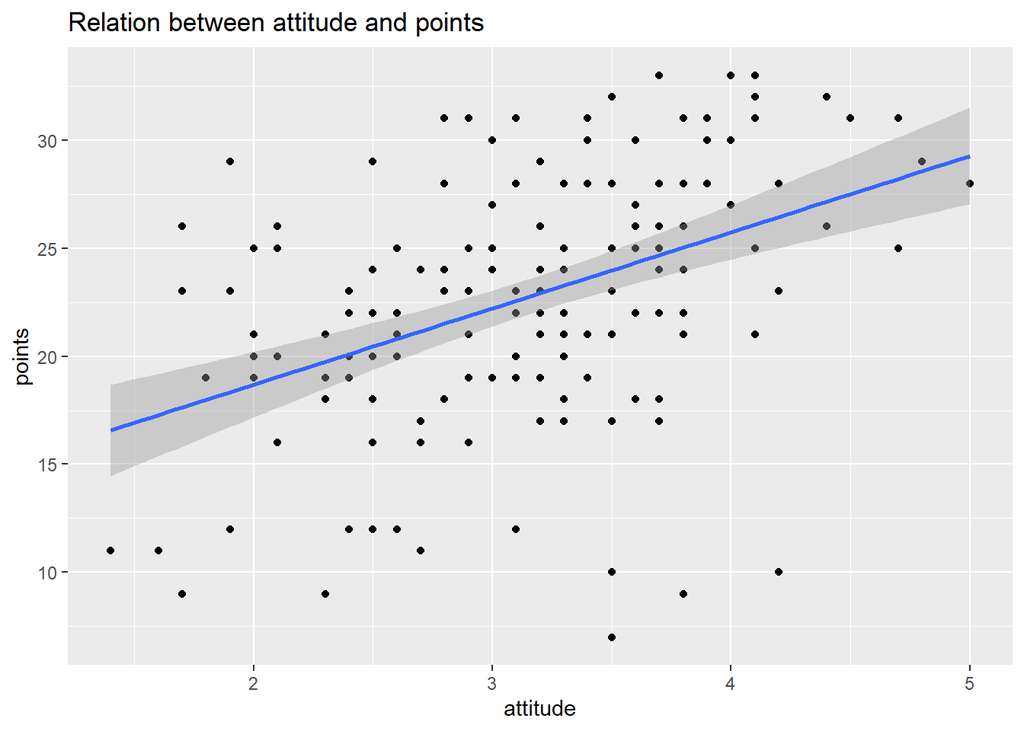

```r
p1 <- ggplot(learning2014, aes(x = attitude, y = points))
p2 <- p1 + geom_point()
p3 <- p2 + geom_smooth(method = "lm")
p4 <- p3 + ggtitle( "Relation between attitude and points")
print (p4)
```

## A linear model to the data. Points are explained by attitude.

The equation for the model is
$$Y_i = \alpha + \beta_1 X_i + \epsilon_i$$
where Y represent points, X is attitude, $\alpha$ is constant, $\beta_1$ is regression coefficient for attitude, and $\epsilon$ is a random term.

```r
m1 <- lm(learning2014$points ~learning2014$attitude, data = learning2014)
results <- summary(m1)
knitr::kable(results$coefficients, digits=3, caption="Regression coefficients")
```

Regression coefficients

|  | Estimate | Std. Error | t value | Pr(>\|t\|) |
| --- | --- | --- | --- | --- |
| (Intercept) | 11.637 | 1.830 | 6.358 | 0 |
| learning2014$attitude | 3.525 | 0.567 | 6.214 | 0 |

Intercept as well as attitude are statistically significant predictors. Coefficient of determination $R^2$ = 0.1905537 that is not particularly high.

## Question 5: Diagnostic plots

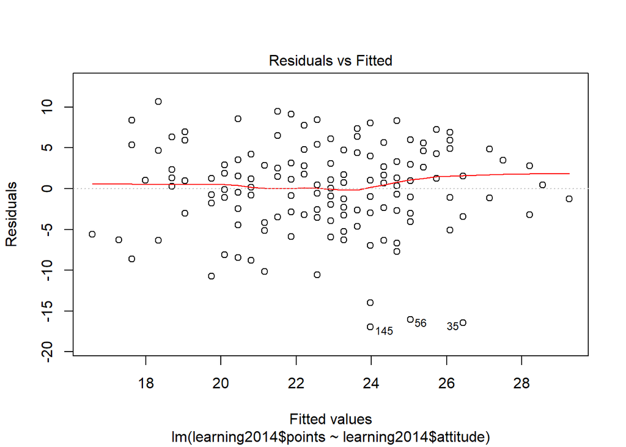

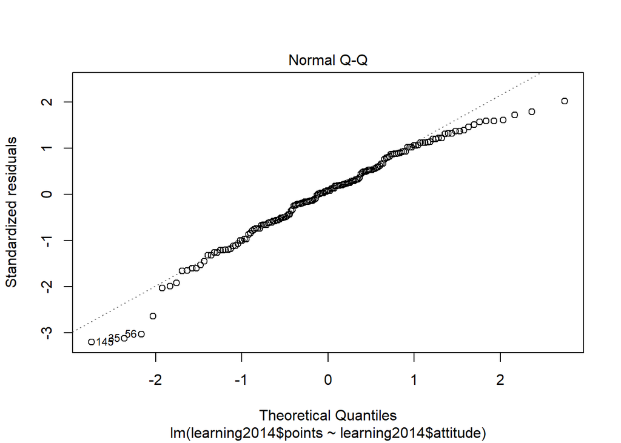

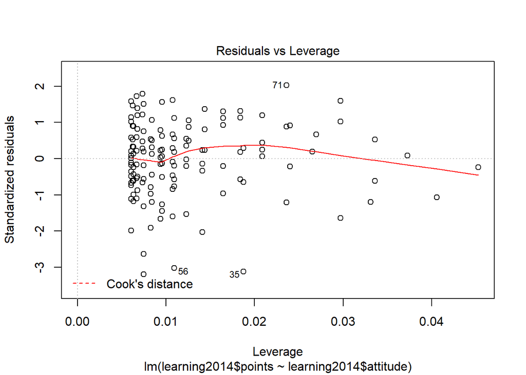

```r
plot(m1, which=c(1,2,5))
```